# Experimentation of Modelling of Customer Spend Cycle

Joseph Bolton

02 April, 2020

```r
library(tidyverse)
```

Some customers buy in cycles. For example, a customer might regularly replenish a particular cosmetics product. Is there a simple way to model this behaviour using only the dates of their transactions?

I’ve documented my experiments here.

For example, consider the following observed transaction times for a single customer: (lines indicate transactions, numbers the time between the transactions)

```
##  [1]   0   8  33  48 104 110 137 149 204 214 244 254 306 316 341 352 405 411 439
## [20] 455
```

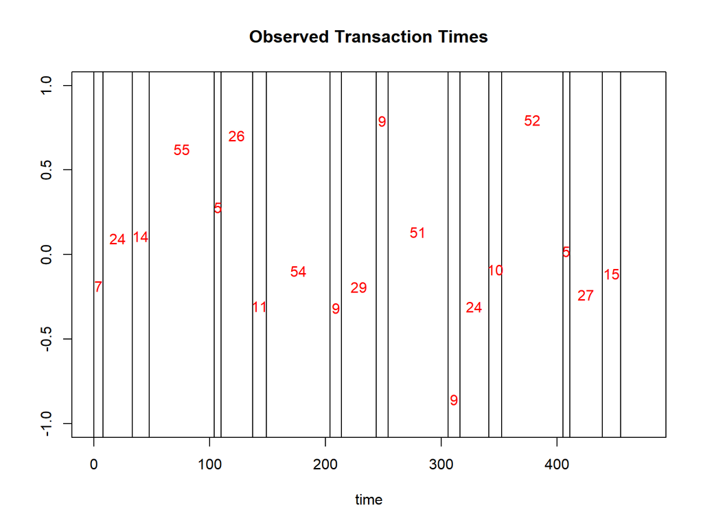

# Model 1: Iterative Period/Cycle Grid Method

My idea here is that if someone is showing cyclic behaviour, then there is some period length and cycle length for which this cyclic behaviour can be captured.

Let’s try this out on the simulated data:

If we break up this persons transactions into periods of length 15, then the transactions look like this:

```
## spend times:
## 0 8 33 48 104 110 137 149 204 214 244 254 306 316 341 352 405 411 439 455
##
## # A tibble: 31 x 2
##    period    transacted
##    <chr>          <dbl>
##  1 [0,15]             1
##  2 (15,30]            0
##  3 (30,45]            1
##  4 (45,60]            1
##  5 (60,75]            0
##  6 (75,90]            0
##  7 (90,105]           1
##  8 (105,120]          1
##  9 (120,135]          0
## 10 (135,150]          1
## # ... with 21 more rows
```

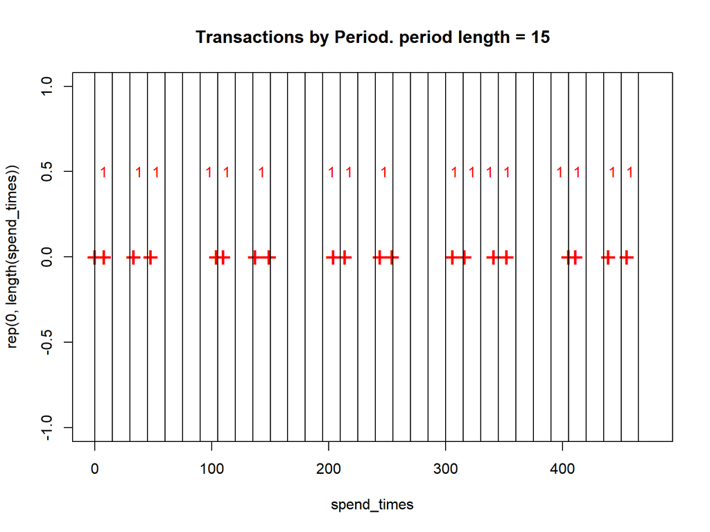

Let’s see how these transactions fit into a cycle of 3 periods:

```
## [1] "NOTE: first 1 observation(s) removed to divide into cycles of length 3"
```

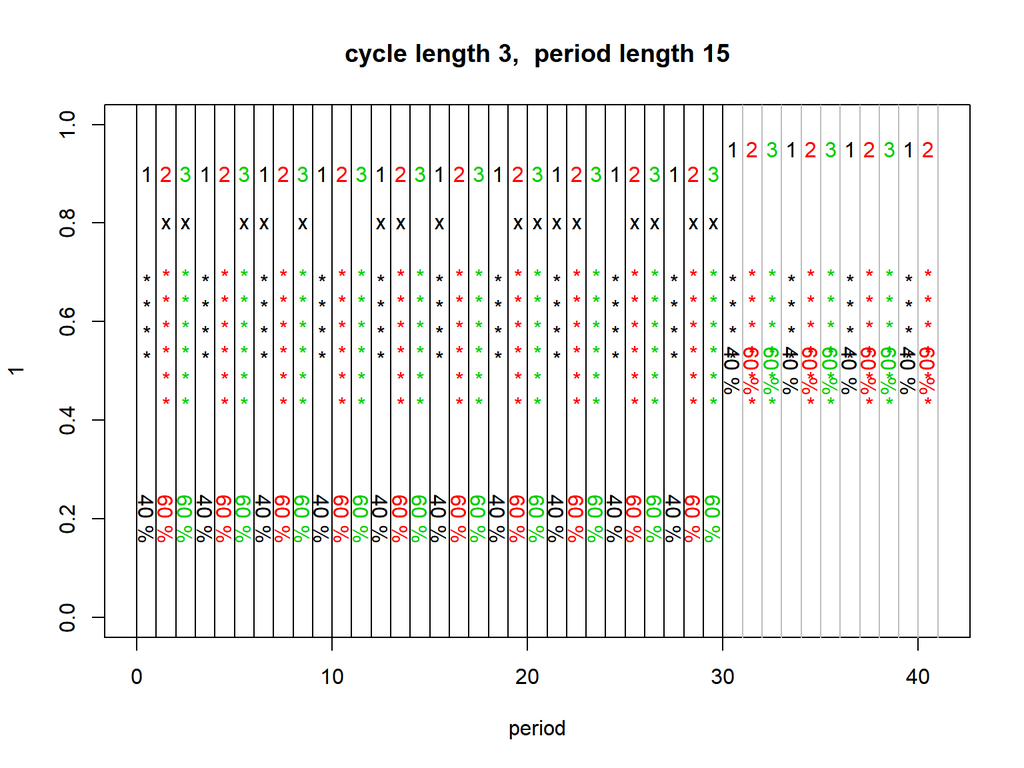

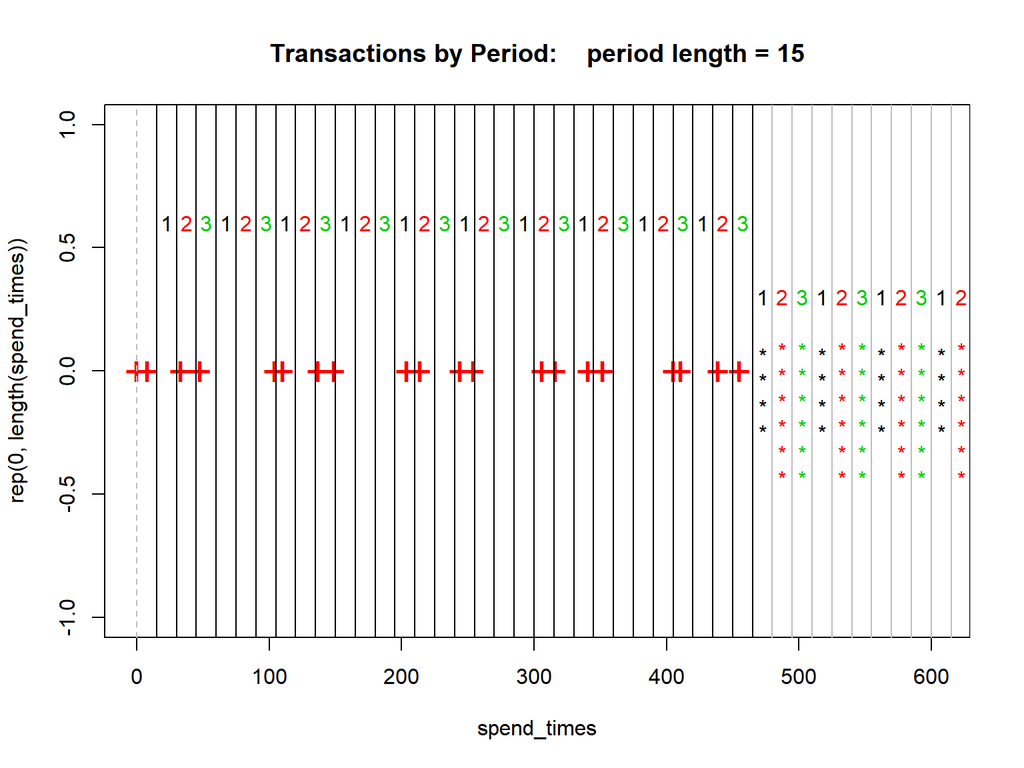

```
## $cycle_1
##  [1] 0 0 1 0 1 1 0 1 0 0
##
## $cycle_2
##  [1] 1 0 0 0 1 0 1 1 1 1
##
## $cycle_3
##  [1] 1 1 1 0 0 0 1 0 1 1
```

```
## proportion of times transacted per cycle:
```

```
## $cycle_1
## [1] 0.4
##
## $cycle_2
## [1] 0.6
##
## $cycle_3
## [1] 0.6
```

Answer: very badly.

This doesn’t seem like a very good fit.

We can measure the *purity* of each cycle (i.e. cycle contains mostly the same value) using a metric such as *variance*, *entropy* or *gini*:

```
## variance:
```

```
## $cycle_1
## [1] 0.2666667
##
## $cycle_2
## [1] 0.2666667
##
## $cycle_3
## [1] 0.2666667
```

```
##
##  gini:
```

```
## $cycle_1
## [1] 0.48
##
## $cycle_2
## [1] 0.48
##
## $cycle_3
## [1] 0.48
```

```
##
##  entropy:
```

```
## $cycle_1
## [1] 0.6730117
##
## $cycle_2
## [1] 0.6730117
##
## $cycle_3
## [1] 0.6730117
```

We could use the average (mean) value of one of these metrics as a measure of the goodness-of-fit of a cycle and period-length that we’re considering:

| metric | avg_value |
| --- | --- |
| variance | 0.2666667 |
| gini | 0.4800000 |
| entropy | 0.6730117 |

The best model by *gini* metric is:

```
## [1] "NOTE: first 2 observation(s) removed to divide into cycles of length 4"
```

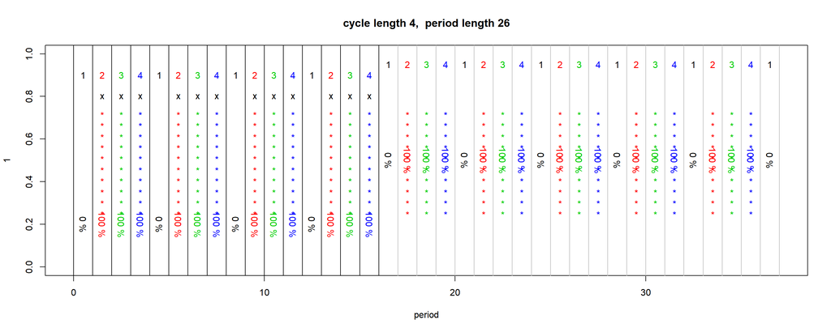

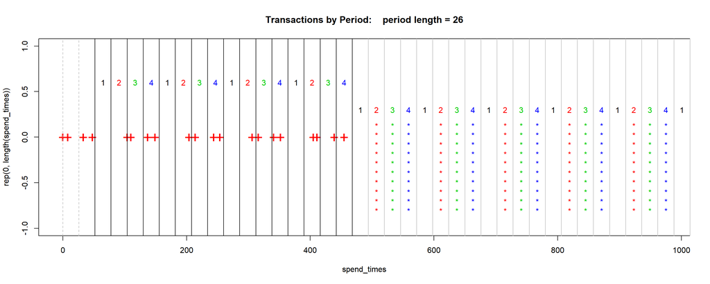

```
## $transactions
## $transactions$cycle_1
## [1] 0 0 0 0
##
## $transactions$cycle_2
## [1] 1 1 1 1
##
## $transactions$cycle_3
## [1] 1 1 1 1
##
## $transactions$cycle_4
## [1] 1 1 1 1
##
##
## $percent_time_transacted_per_cycle
## $percent_time_transacted_per_cycle$cycle_1
## [1] 0
##
## $percent_time_transacted_per_cycle$cycle_2
## [1] 1
##
## $percent_time_transacted_per_cycle$cycle_3
## [1] 1
##
## $percent_time_transacted_per_cycle$cycle_4
## [1] 1
##
##
## $cycle_variance
## $cycle_variance$cycle_1
## [1] 0
##
## $cycle_variance$cycle_2
## [1] 0
##
## $cycle_variance$cycle_3
## [1] 0
##
## $cycle_variance$cycle_4
## [1] 0
```

[output cut: 23 more lines]

```
## $cycle_entropy$cycle_1
## [1] NaN
##
## $cycle_entropy$cycle_2
## [1] NaN
##
## $cycle_entropy$cycle_3
## [1] NaN
##
## $cycle_entropy$cycle_4
## [1] NaN
##
##
## $mean_entropy
## [1] NaN
```